# Correlation

Ziyuan Huang

Last Updated: 2026-01-22

**Machine:** MEL_DEL - Windows 10 x64

# What is a Correlation?

- **Definition:** It is a way of measuring the extent to which two variables are related.
- Correlation indicates the direction and strength of the relationship across variables.
  - Direction: none, positive, negative
  - Strength: none (0) to perfect (1 or -1)

# Visualizing Correlation

- No relationship

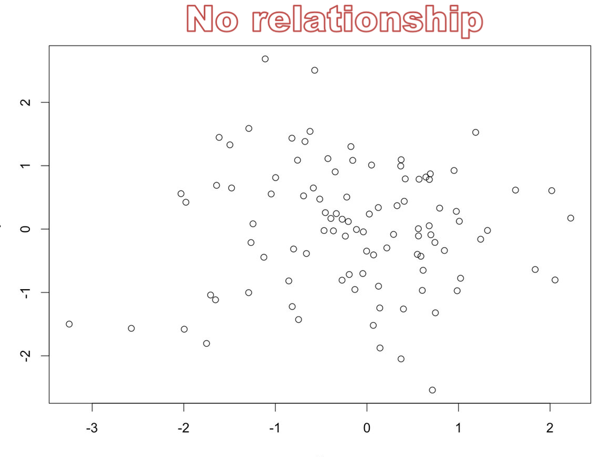

# Visualizing Correlation

- Positive relationship

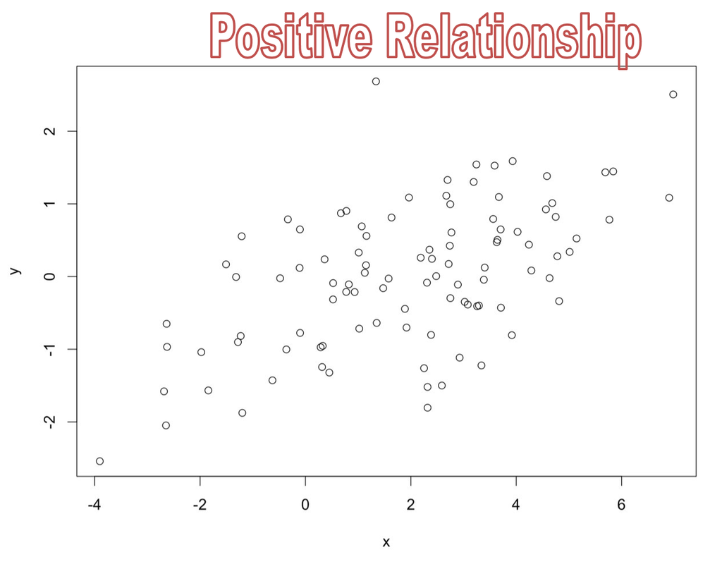

# Visualizing Correlation

- Negative relationship

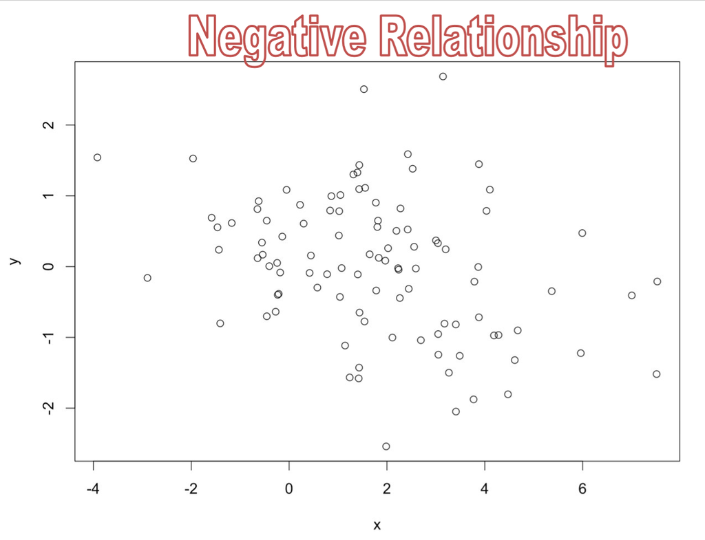

# Using Scatterplots

- **Plotting reminder:**
- ggplot(data, aes(X, Y, color/fill = categorical)
  - ,+ cleanup coding
  - ,+ geom_point() to get the dots
  - ,+ geom_smooth() to get a line
  - ,+ xlab/ylab
- We can additionally control the length of the X and Y axes with `coord_cartesian()`.
  - coord_cartesian(xlim = NULL, ylim = NULL)
  - coord_cartesian(xlim = c(0,100), ylim = c(0,101))

# Using Scatterplots

```r
# Load required libraries
library(rio)        # Data import
library(ggplot2)    # Visualization
library(corrplot)   # Correlation matrix visualization
library(GGally)     # ggpairs for scatterplot matrices
library(Hmisc)      # rcorr() function
library(ppcor)      # Partial correlations

# Define cleanup theme for professional graphs
cleanup <- theme(panel.grid.major = element_blank(),
                panel.grid.minor = element_blank(),
                panel.background = element_blank(),
                axis.line.x = element_line(color = "black"),
                axis.line.y = element_line(color = "black"),
                legend.key = element_rect(fill = "white"),
                text = element_text(size = 15))

# Import datasets
exam <- import("data/exam_data.csv")
liar <- import("data/liar_data.csv")
```

# Using Scatterplots

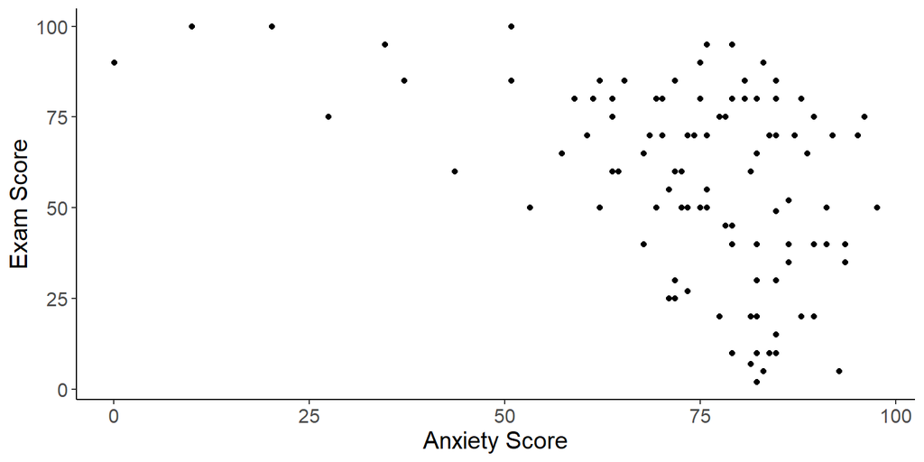

```r
#from chapter 5 notes
scatter <- ggplot(exam, aes(Anxiety, Exam))
scatter +
  geom_point() +
  xlab("Anxiety Score") +
  ylab("Exam Score") +
  cleanup
```

# Using Scatterplots

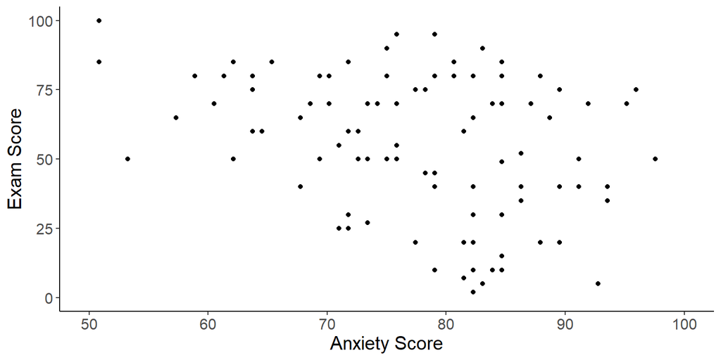

```r
#from chapter 5 notes + coord_cartesian
scatter <- ggplot(exam, aes(Anxiety, Exam))
scatter +
  geom_point() +
  xlab("Anxiety Score") +
  ylab("Exam Score") +
  cleanup +
  coord_cartesian(xlim = c(50,100), ylim = c(0,100))
```

```r
  #just example numbers, you would want to use the real scale of the data
```

# Modeling Relationships

- Remember, our all-in-one statistical equation:
  - $Outcome_i = Model + Error_i$
- We have previously defined our model as the Mean and the Standard Deviation or Standard Error.
- We used the SE to determine if our model “fit” well.

# Modeling Relationships

- Now, we can use:
  - $Outcome_i = \beta X_i + Error_i$
- Correlation is a type of simple standardized regression, which is what this equation represents.
- When you have one X and one Y variable, *r* and $\beta$ are equal.
- Now we are using *r* or $\beta$ to determine the strength of the model.
- Traditionally you don’t see the error values reported (sometimes you see CI).

# Measuring Relationships

- How do we measure the direction and strength of the relationship of variables?
- We need to see whether as one variable increases, the other increases, decreases or stays the same.
- This relationship can be found by calculating the covariance.
  - We look at how much each score deviates from the mean.
  - If both variables deviate from the mean by the same amount, they are likely to be related.

# Revision of Variance

- The **variance** tells us by how much scores deviate from the mean for a single variable.
- We also described the variance as the sum of squares divided by degrees of freedom.

$$SD^2 = \frac
{\sum(X_i-\bar{X})^2}{N-1}$$

- Or we could write it like this:

$$SD^2 = \frac
{\sum(X_i-\bar{X})(X_i-\bar{X})}{N-1}$$

# Revision of Variance

- **Covariance** is similar - it tells is by how much scores on two variables differ from their respective means.

$$Cov(x,y) = \frac
{\sum(X_i-\bar{X})(Y_i-\bar{Y})}{N-1}$$

# Revision of Variance: Calculating Variance

```r
var(exam$Revise)
```

```
## [1] 329.7531
```

```r
var(exam$Exam)
```

```
## [1] 672.9138
```

# Revision of Variance: Calculating Covariance

```r
cov(exam$Revise, exam$Exam)
```

```
## [1] 186.8784
```

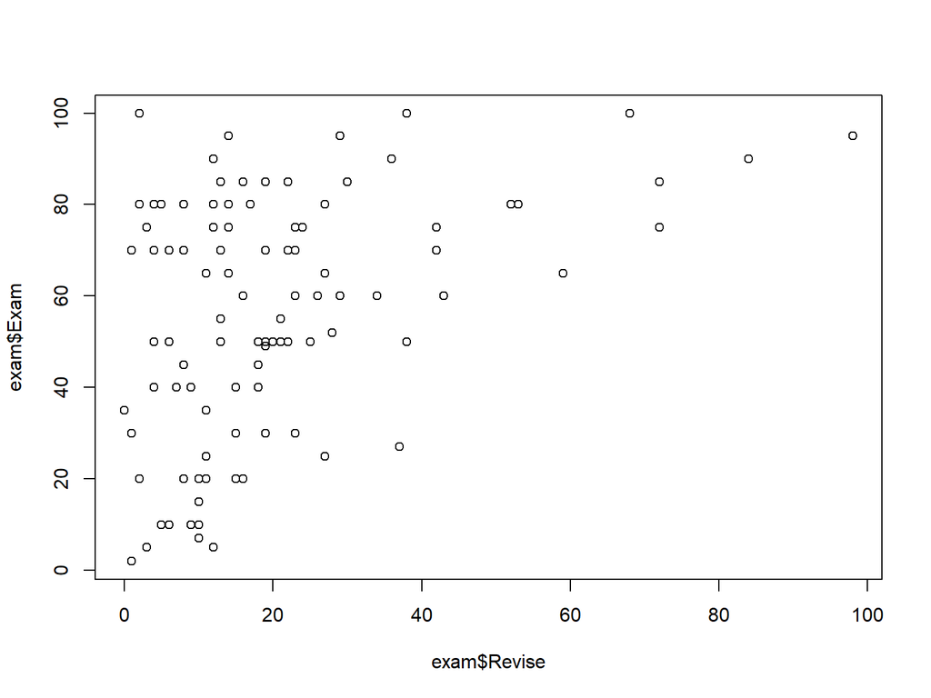

```r
plot(exam$Revise, exam$Exam)
```

# Problems with Covariance

- It depends upon the units of measurement.
- One solution: standardize it!
  - Divide by the standard deviations of both variables.
- The standardized version of covariance is known as the correlation coefficient.
  - It is relatively unaffected by units of measurement.

# The Correlation Coefficient

$$r = \frac{Cov(x,y)}{S_xS_y}$$

$$r =
\frac{\sum(X_i-\bar{X})(Y_i-\bar{Y})}{(N-1)S_xS_y}$$

- We can just look at *r* to determine the strength of relationship.
- We can also calculate the confidence interval or standard error for *r*. It has traditionally not been quite as popular because of the annoyance of calculating it. *R* makes this easy!
- We can use this confidence interval to assess model fit.

# The Correlation Coefficient

- It varies between -1 and +1
  - 0 = no relationship
- It is an effect size
  - .1 = small effect
  - .3 = medium effect
  - .5 = large effect
  - Remember, that these are guidelines.

# The Correlation Coefficient

- Coefficient of determination, $r^2$
  - By squaring the value of *r* you get the proportion of variance in one variable shared by the other.

# R versus r

- $R$ = correlation coefficient for 3+ variables (you will see this in the regression chapter).
- $r$ = correlation coefficient for 2 variables.
- $r^2$ = coefficient of determination for 2 variables.
- $R^2$ = coefficient of determination for 3+ variables.
- In reality, we often use $R^2$ for anything effect size related, even if it’s only 2.

# Correlation: Example

- The correlation between exam revisions and exam scores is **positive** and **medium**.
- Correlation coefficient (r) = 0.397

```r
cor(exam$Revise, exam$Exam, use = "complete.obs")
```

```
## [1] 0.3967207
```

# Visualizing Correlations: Modern Approaches

- **Why visualize?** Anscombe’s Quartet shows identical correlations (r=0.82) but totally different relationships!
- Modern R offers several powerful visualization tools for correlations

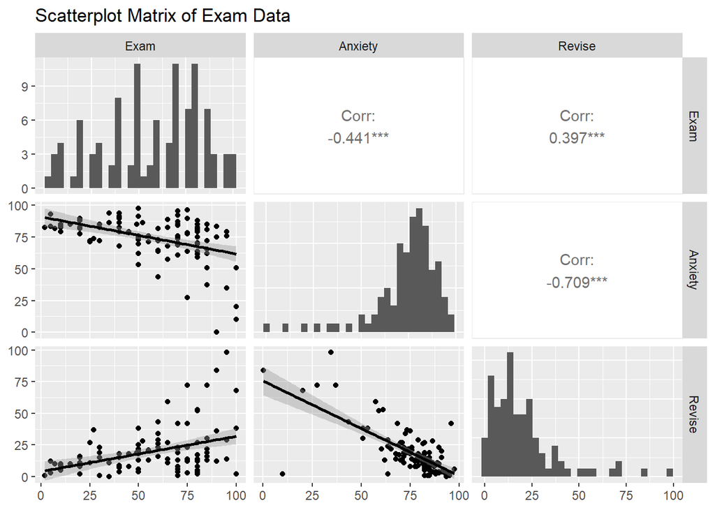

```r
# Quick scatterplot matrix with ggpairs()
ggpairs(exam[, c("Exam", "Anxiety", "Revise")],
        title = "Scatterplot Matrix of Exam Data",
        lower = list(continuous = "smooth"),
        diag = list(continuous = "barDiag"))
```

# Correlation: Example

- Correlation is an effect size and can be used for statistical testing. What should I check for data screening?
  - Accuracy
  - Missing (pairwise exclusion may be useful)
  - Outliers
  - Normality
  - Linearity
  - Homogeneity
  - Homoscedasticity

# Assumptions for Correlation

- Before running correlation analysis, check these assumptions:
  - **Accuracy**: No data entry errors
  - **Missing data**: Handle appropriately (pairwise or listwise deletion)
  - **Outliers**: Can dramatically affect correlation coefficients
  - **Normality**: Required for Pearson’s correlation (use Spearman/Kendall if violated)
  - **Linearity**: Relationship should be linear, not curved
  - **Homoscedasticity**: Variance should be consistent across range
- **Reference**: Field, Miles, & Field (2012), Chapter 6

# Correlation: Understanding the NHST

- Remember that we discussed NHST as a framework for understanding the results of a statistical test.
- For correlation, we might consider using:
  - H0: The correlation between exam performance and exam revisions is zero (ρ = 0).
  - H1: The correlation between exam performance and exam revisions is not zero (ρ ≠ 0).

# Correlation: Understanding the NHST

- We can use many different forms of this type of set up:
  - H0: The correlation between exam performance and exam revisions is less than .1
  - H1: The correlation between exam performance and exam revisions is greater than .1

# Correlation: Understanding the NHST

- The main “rule” is that the two hypotheses are opposites and cover the entire range of possibilities. For example, here’s an incompatible set up:
  - H0: The correlation between exam performance and exam revisions is zero.
  - H1: The correlation between exam performance and exam revisions is greater than .1
  - What do you do if the relationship is negative?

# Correlation: How to Calculate

- We’ve already used `cor()` during data screening.
- But what about *p* values for our statistical test? What does a *p* value tell us again?
- Also, what about confidence intervals and other types of correlation?

# Correlation: Three Main Functions in R

- **Field et al. (2012, pp. 269-272) describe three key functions:**

| Function | Methods | Multiple Vars | p-values | CI | Best Use |
| --- | --- | --- | --- | --- | --- |
| `cor()` | All 3 | ✓ | ✗ | ✗ | Quick exploration |
| `rcorr()` | P, S | ✓ | ✓ | ✗ | Matrix with p-values |
| `cor.test()` | All 3 | ✗ | ✓ | ✓ | Single pair, full stats |

- **Methods**: P = Pearson, S = Spearman, K = Kendall

# Correlation: How to Calculate

- **cor() function will calculate:**
  - Pearson, Spearman, Kendall
  - Multiple correlations at once
  - No p-values
  - No confidence intervals
  - **Use case**: Quick correlation matrix for data screening

# Correlation Matrix: Numeric Methods

- Note: here we have gender as a numeric value, we will come back to that issue in a little bit.

```r
# Pearson correlation matrix
cor(exam[ , -1],
    use = "pairwise.complete.obs",  # Handle missing data
    method = "pearson")
```

```
##              Revise         Exam     Anxiety       Gender
## Revise   1.00000000  0.396720697 -0.70924926  0.085350584
## Exam     0.39672070  1.000000000 -0.44099341 -0.004674066
## Anxiety -0.70924926 -0.440993412  1.00000000 -0.002365840
## Gender   0.08535058 -0.004674066 -0.00236584  1.000000000
```

```r
# Kendall's tau (better for small samples, tied ranks)
cor(exam[ , -1],
    use = "pairwise.complete.obs",
    method = "kendall")
```

```
##              Revise         Exam     Anxiety       Gender
## Revise   1.00000000  0.263325853 -0.48856004  0.099160691
## Exam     0.26332585  1.000000000 -0.28479188 -0.007164456
## Anxiety -0.48856004 -0.284791876  1.00000000  0.018699690
## Gender   0.09916069 -0.007164456  0.01869969  1.000000000
```

# Visualizing Correlation Matrix

- **Modern approach using corrplot** (Field et al., 2012, pp. 270-271)

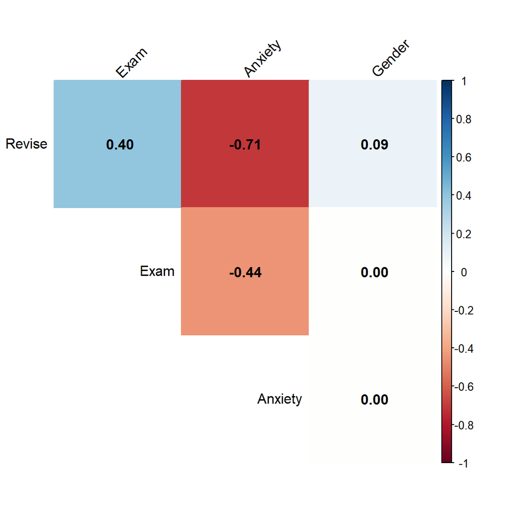

```r
# Create correlation matrix
cor_matrix <- cor(exam[ , -1], use = "pairwise.complete.obs")

# Visualize with corrplot
corrplot(cor_matrix,
         method = "color",        # Color-coded cells
         type = "upper",          # Show upper triangle only
         addCoef.col = "black",   # Add correlation coefficients
         tl.col = "black",        # Text label color
         tl.srt = 45,             # Text label rotation
         diag = FALSE)            # Hide diagonal
```

# Correlation: rcorr() with p-values

- **rcorr() function will calculate:**
  - Pearson, Spearman (not Kendall)
  - Multiple correlations at once
  - Includes p values
  - No confidence intervals
  - **Note**: Must convert data to matrix with `as.matrix()`

```r
# rcorr() requires matrix input
rcorr(as.matrix(exam[ , -1]), type = "pearson")
```

```
##         Revise  Exam Anxiety Gender
## Revise    1.00  0.40   -0.71   0.09
## Exam      0.40  1.00   -0.44   0.00
## Anxiety  -0.71 -0.44    1.00   0.00
## Gender    0.09  0.00    0.00   1.00
##
## n= 103
##
##
## P
##         Revise Exam   Anxiety Gender
## Revise         0.0000 0.0000  0.3913
## Exam    0.0000        0.0000  0.9626
## Anxiety 0.0000 0.0000         0.9811
## Gender  0.3913 0.9626 0.9811
```

- **Output**: Three matrices - correlations (r), sample sizes (n), and p-values (P)
- **Field et al. (2012, p. 272)**: rcorr() rounds to 2 decimal places

# Correlation: cor.test() with Full Statistics

- **cor.test() function will calculate:**
  - Pearson, Spearman, Kendall
  - One correlation at a time
  - Includes p values
  - **Includes confidence interval** (only function that does!)
  - Test statistic (t, S, or z depending on method)

```r
# Full statistical test for single correlation
cor.test(exam$Revise,
         exam$Exam,
         method = "pearson",
         alternative = "two.sided",  # or "greater", "less"
         conf.level = 0.95)          # 95% CI
```

```
##
##  Pearson's product-moment correlation
##
## data:  exam$Revise and exam$Exam
## t = 4.3434, df = 101, p-value = 3.343e-05
## alternative hypothesis: true correlation is not equal to 0
## 95 percent confidence interval:
##  0.2200938 0.5481602
## sample estimates:
##       cor
## 0.3967207
```

# Interpreting cor.test() Output

```
##
##  Pearson's product-moment correlation
##
## data:  exam$Revise and exam$Exam
## t = 4.3434, df = 101, p-value = 3.343e-05
## alternative hypothesis: true correlation is not equal to 0
## 95 percent confidence interval:
##  0.2200938 0.5481602
## sample estimates:
##       cor
## 0.3967207
```

- **t-value**: Test statistic (tests H0: ρ = 0)
- **df**: Degrees of freedom = n - 2
- **p-value**: Probability of obtaining this r if H0 is true
- **95% CI**: We’re 95% confident true ρ is in this interval
- **cor**: Sample correlation coefficient (r = 0.397)

# Correlation Interpretation

- **The third-variable problem:**
  - In any correlation, causality between two variables cannot be assumed because there may be other measured or unmeasured variables that potentially affect the results.
- **Direction of causality:**
  - Correlation coefficients say nothing about which variable causes the other to change.

# Nonparametric Correlation

- **When to use**: Violations of normality or presence of outliers
- **Field et al. (2012, pp. 277-279)** describe two non-parametric alternatives:
- **Spearman’s Rho (rs)**:
  - Pearson’s correlation applied to ranked data
  - Converts scores to ranks, then calculates correlation
  - Good for monotonic (consistently increasing/decreasing) relationships
  - Use when: Ordinal data or non-normal continuous data
- **Kendall’s Tau (τ)**:
  - Based on concordant vs. discordant pairs
  - Better for small samples (n < 30)
  - Better handling of tied ranks
  - More robust to outliers
  - **Preferred by Field et al. for non-parametric data**

# Correlation: Example - Liar Dataset

- Dataset from Field et al. (2012) - World’s Best Liar Competition:
  - **Sample**: 68 contestants
  - **Variables**:
    - `Position`: Competition placement (1st, 2nd, 3rd, etc.) - **Ordinal**
    - `Creativity`: Questionnaire score (0-60) - Continuous
    - `Novice`: First time vs. returning competitor - Binary

```r
str(liar)
```

```
## 'data.frame':    68 obs. of  3 variables:
##  $ Creativity: int  53 36 31 43 30 41 32 54 47 50 ...
##  $ Position  : int  1 3 4 2 4 1 4 1 2 2 ...
##  $ Novice    : chr  "First Time" "Had entered Competition Before" "First Time" "First Time" ...
```

```r
summary(liar)
```

```
##    Creativity       Position        Novice
##  Min.   :21.00   Min.   :1.000   Length:68
##  1st Qu.:35.00   1st Qu.:1.000   Class :character
##  Median :39.00   Median :2.000   Mode  :character
##  Mean   :39.99   Mean   :2.221
##  3rd Qu.:45.25   3rd Qu.:3.000
##  Max.   :56.00   Max.   :6.000
```

# Why Non-Parametric for Liar Data?

- **Position is ordinal**: Rankings (1st, 2nd, 3rd) are ordered but intervals aren’t equal
- Distance between 1st and 2nd ≠ distance between 50th and 51st
- **Pearson assumes interval/ratio data** with equal intervals
- **Solution**: Use Spearman’s rs or Kendall’s τ which work with ranks

# Correlation: Comparing Methods on Liar Data

- **Spearman’s Rho**

```r
with(liar, cor.test(Creativity, Position, method = "spearman"))
```

```
##
##  Spearman's rank correlation rho
##
## data:  Creativity and Position
## S = 71948, p-value = 0.00172
## alternative hypothesis: true rho is not equal to 0
## sample estimates:
##        rho
## -0.3732184
```

- **Kendall’s Tau** (preferred for this data)

```r
with(liar, cor.test(Creativity, Position, method = "kendall"))
```

```
##
##  Kendall's rank correlation tau
##
## data:  Creativity and Position
## z = -3.2252, p-value = 0.001259
## alternative hypothesis: true tau is not equal to 0
## sample estimates:
##        tau
## -0.3002413
```

# Interpreting Non-Parametric Results

- **Both methods show negative relationship**: More creative → better placement (lower number)
- **Spearman rs = -0.373**: Moderate negative correlation
- **Kendall τ = -0.300**: Similar strength, slightly more conservative
- **Both significant** (p < 0.01): Relationship unlikely due to chance
- **Field et al. (2012, p. 279)**: Report Kendall’s tau for ordinal data with tied ranks

# Visualizing the Liar Data Relationship

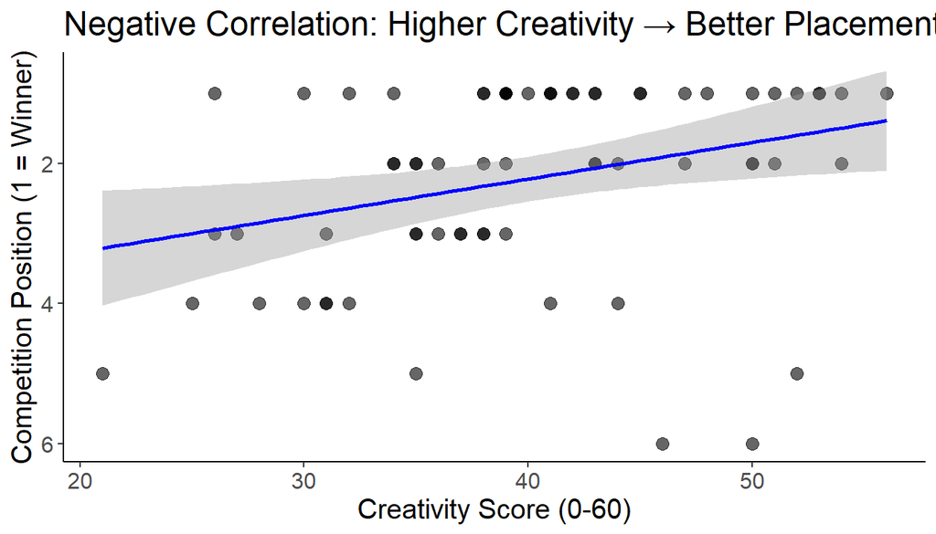

```r
scatter <- ggplot(liar, aes(Creativity, Position))
scatter +
  geom_point(size = 3, alpha = 0.6) +
  geom_smooth(method = "lm", se = TRUE, color = "blue") +
  xlab("Creativity Score (0-60)") +
  ylab("Competition Position (1 = Winner)") +
  ggtitle("Negative Correlation: Higher Creativity → Better Placement") +
  cleanup +
  scale_y_reverse()  # Reverse Y so winners at top
```

# Correlation: Example

- All values must be numeric to be able to do any of these correlations.
- Therefore, if you have any variables that import with labels, you will have defactor them using `as.numeric()`.
- What type of correlation should we use with **binary** predictors?
  - When using correlation on binary outcomes, you are essentially creating a standardized difference between the group means.
  - *t*-tests will give you equivalent answers and may be more interpretable.

# Correlation: Biserial and Point-Biserial

- **Field et al. (2012, pp. 280-282)** discuss correlations with binary variables:
- **Point-Biserial Correlation (rpb)**:
  - Used when one variable is **truly dichotomous** (natural binary)
  - Examples: Biological sex, alive/dead, yes/no responses
  - No underlying continuum
- **Biserial Correlation (rb)**:
  - Used when binary variable is **artificially dichotomized**
  - Examples: Pass/fail from continuous test score, high/low from median split
  - Assumes underlying continuous distribution
  - **Higher values** than point-biserial (accounts for artificial split)

# Point-Biserial Example

```r
# Convert character variable to numeric (1, 2)
liar$Novice2 <- as.numeric(as.factor(liar$Novice))
str(liar$Novice2)
```

```
##  num [1:68] 1 2 1 1 2 1 1 2 2 1 ...
```

```r
# Correlation between creativity and novice status
with(liar, cor.test(Creativity, Novice2))
```

```
##
##  Pearson's product-moment correlation
##
## data:  Creativity and Novice2
## t = -2.1969, df = 66, p-value = 0.03154
## alternative hypothesis: true correlation is not equal to 0
## 95 percent confidence interval:
##  -0.47020478 -0.02412131
## sample estimates:
##        cor
## -0.2610451
```

# Visualizing Point-Biserial Correlation

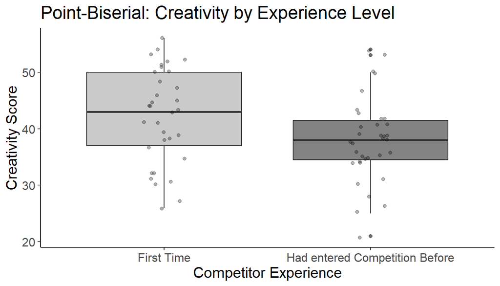

```r
# Better visualization with boxplot
ggplot(liar, aes(x = Novice, y = Creativity, fill = Novice)) +
  geom_boxplot(alpha = 0.7) +
  geom_jitter(width = 0.1, alpha = 0.3) +
  xlab("Competitor Experience") +
  ylab("Creativity Score") +
  ggtitle("Point-Biserial: Creativity by Experience Level") +
  cleanup +
  scale_fill_manual(values = c("grey70", "grey30")) +
  theme(legend.position = "none")
```

# Important Note on Binary Correlations

- **Point-biserial correlation produces same result as independent t-test**
- Mathematically equivalent: $r_{pb} = \frac{t}{\sqrt{t^2 + df}}$
- **Field et al. (2012, p. 281)**: t-test may be more interpretable for binary predictors
- Use correlation when: Part of larger correlation matrix
- Use t-test when: Comparing two groups is primary research question

# Comparing Correlations

- **Research question**: Are two correlation coefficients significantly different?
- **Field et al. (2012, pp. 285-288)** describe different scenarios
- **Modern solution**: Use **cocor** package (Diedenhofen & Musch, 2015)

# Types of Correlation Comparisons

- **First,** you must determine the comparison type:
1. **Independent correlations**:
   - Correlations from **separate groups** (e.g., men vs. women)
   - Same variables in both groups
   - Example: Is r(anxiety, performance) different between control vs. treatment?
2. **Dependent correlations - Overlapping**:
   - Same people, different variables sharing one variable
   - Example: Compare r(X,Y) vs. r(X,Z) in same sample
3. **Dependent correlations - Non-overlapping**:
   - Same people, completely different variable pairs
   - Example: Compare r(W,X) vs. r(Y,Z) in same sample

# Independent Correlations

- There’s no split/subset function within cocor.
- Therefore, you have to split up the dataset on your independent variable, and then put it back together in `list` format.
- Subset the data, then create a list.
  - cocor(~ X + Y | X + Y, data = data)
  - Fill in X and Y with your variables you want to correlate (on these they are likely to be the same).
  - Data = new list we just created.

# Independent Correlations

```r
library(cocor)
new <- subset(liar, Novice == "First Time")
old <- subset(liar, Novice == "Had entered Competition Before")
ind_data <- list(new, old)
cocor(~Creativity + Position | Creativity + Position,
      data = ind_data)
```

```
##
##   Results of a comparison of two correlations based on independent groups
##
## Comparison between r1.jk (Creativity, Position) = -0.2123 and r2.hm (Creativity, Position) = -0.3802
## Difference: r1.jk - r2.hm = 0.1679
## Data: ind_data: j = Creativity, k = Position, h = Creativity, m = Position
## Group sizes: n1 = 33, n2 = 35
## Null hypothesis: r1.jk is equal to r2.hm
## Alternative hypothesis: r1.jk is not equal to r2.hm (two-sided)
## Alpha: 0.05
##
## fisher1925: Fisher's z (1925)
##   z = 0.7268, p-value = 0.4673
##   Null hypothesis retained
##
## zou2007: Zou's (2007) confidence interval
##   95% confidence interval for r1.jk - r2.hm: -0.2792 0.6027
##   Null hypothesis retained (Interval includes 0)
```

# Dependent Correlations

- `cocor(~ X + Y | Y + Z, data = data)` - Overlapping correlation
- Fill in X, Y, Z with your variables you want to correlate
- You can also have `X + Y | Q + Z` - Non-overlapping correlation
- Data is the dataframe with all of the columns

# Dependent Correlations

```r
cocor(~Revise + Exam | Revise + Anxiety,
      data = exam)
```

```
##
##   Results of a comparison of two overlapping correlations based on dependent groups
##
## Comparison between r.jk (Revise, Exam) = 0.3967 and r.jh (Revise, Anxiety) = -0.7092
## Difference: r.jk - r.jh = 1.106
## Related correlation: r.kh = -0.441
## Data: exam: j = Revise, k = Exam, h = Anxiety
## Group size: n = 103
## Null hypothesis: r.jk is equal to r.jh
## Alternative hypothesis: r.jk is not equal to r.jh (two-sided)
## Alpha: 0.05
##
## pearson1898: Pearson and Filon's z (1898)
##   z = 10.1802, p-value = 0.0000
##   Null hypothesis rejected
##
## hotelling1940: Hotelling's t (1940)
##   t = 9.3238, df = 100, p-value = 0.0000
##   Null hypothesis rejected
##
## williams1959: Williams' t (1959)
##   t = 8.9261, df = 100, p-value = 0.0000
##   Null hypothesis rejected
##
## olkin1967: Olkin's z (1967)
##   z = 10.1802, p-value = 0.0000
##   Null hypothesis rejected
##
## dunn1969: Dunn and Clark's z (1969)
##   z = 8.0684, p-value = 0.0000
##   Null hypothesis rejected
##
## hendrickson1970: Hendrickson, Stanley, and Hills' (1970) modification of Williams' t (1959)
##   t = 9.2710, df = 100, p-value = 0.0000
##   Null hypothesis rejected
##
## steiger1980: Steiger's (1980) modification of Dunn and Clark's z (1969) using average correlations
##   z = 7.6646, p-value = 0.0000
##   Null hypothesis rejected
##
## meng1992: Meng, Rosenthal, and Rubin's z (1992)
##   z = 7.6896, p-value = 0.0000
##   Null hypothesis rejected
##   95% confidence interval for r.jk - r.jh: 0.9727 1.6382
##   Null hypothesis rejected (Interval does not include 0)
##
## hittner2003: Hittner, May, and Silver's (2003) modification of Dunn and Clark's z (1969) using a backtransformed average Fisher's (1921) Z procedure
##   z = 7.6392, p-value = 0.0000
##   Null hypothesis rejected
##
## zou2007: Zou's (2007) confidence interval
##   95% confidence interval for r.jk - r.jh: 0.8698 1.3009
##   Null hypothesis rejected (Interval does not include 0)
```

# Partial and Semi-Partial Correlations

- **Field et al. (2012, pp. 289-293)** describe controlling for third variables
- **The third-variable problem**: Observed correlation may be due to confounding variable

# Understanding Partial Correlation

- **Partial correlation (pr)**:
  - Relationship between X and Y, **controlling Z from both X and Y**
  - Removes Z’s effect from both variables
  - Formula: Correlation between residuals of (X predicting Z) and (Y predicting Z)
  - **Question answered**: “What’s the correlation between X and Y after removing Z’s influence on both?”
- **Example**:
  - Raw correlation: Exam performance (Y) and Revision time (X)
  - Control for: Anxiety (Z) affects both revision and performance
  - Partial correlation: Exam-Revision relationship **independent of anxiety**

# Understanding Semi-Partial Correlation

- **Semi-partial correlation (sr)** (also called “part correlation”):
  - Relationship between X and Y, **controlling Z from X only**
  - Removes Z’s effect from predictor, not outcome
  - Formula: Correlation between residuals of (X predicting Z) and raw Y
  - **Question answered**: “What’s the unique contribution of X to Y, after removing Z from X?”
- **Use in regression**:
  - $sr^2$ = unique variance in Y explained by X
  - Sum of all $sr^2$ values = $R^2$ in multiple regression
  - **Field et al. (2012, p. 292)**: Key for understanding unique predictor contributions

# Partial and Semi-Partial Correlations

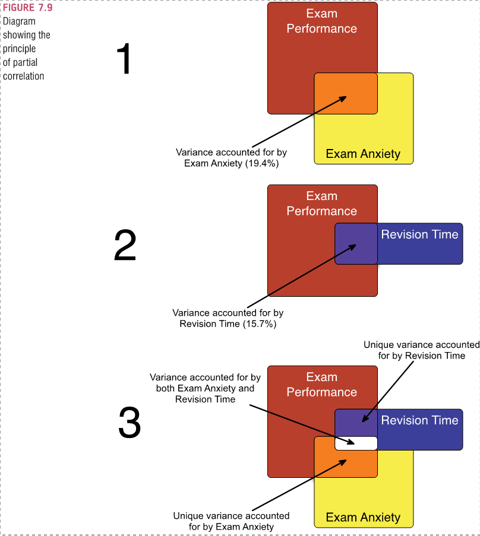

# Partial Correlations in R

```r
# Using ppcor package
pcor(exam[ , -c(1)], method = "pearson")
```

```
## $estimate
##             Revise        Exam    Anxiety      Gender
## Revise   1.0000000  0.13438703 -0.6510138  0.12060588
## Exam     0.1343870  1.00000000 -0.2442316 -0.02247429
## Anxiety -0.6510138 -0.24423163  1.0000000  0.07479920
## Gender   0.1206059 -0.02247429  0.0747992  1.00000000
##
## $p.value
##               Revise       Exam      Anxiety    Gender
## Revise  0.000000e+00 0.18029461 1.703877e-13 0.2296046
## Exam    1.802946e-01 0.00000000 1.384188e-02 0.8234728
## Anxiety 1.703877e-13 0.01384188 0.000000e+00 0.4572346
## Gender  2.296046e-01 0.82347277 4.572346e-01 0.0000000
##
## $statistic
##            Revise       Exam    Anxiety     Gender
## Revise   0.000000  1.3493743 -8.5335224  1.2088373
## Exam     1.349374  0.0000000 -2.5059623 -0.2236729
## Anxiety -8.533522 -2.5059623  0.0000000  0.7463335
## Gender   1.208837 -0.2236729  0.7463335  0.0000000
##
## $n
## [1] 103
##
## $gp
## [1] 2
##
## $method
## [1] "pearson"
```

# Semi-Partial Correlations in R

- **Key difference**: Top and bottom triangles are **not equal** (asymmetric)

```r
spcor(exam[ , -c(1)], method = "pearson")
```

```
## $estimate
##             Revise        Exam     Anxiety      Gender
## Revise   1.0000000  0.09406750 -0.59488837  0.08427039
## Exam     0.1206113  1.00000000 -0.22399075 -0.01999258
## Anxiety -0.5842845 -0.17158155  1.00000000  0.05110095
## Gender   0.1206031 -0.02231536  0.07446008  1.00000000
##
## $p.value
##               Revise       Exam      Anxiety    Gender
## Revise  0.000000e+00 0.34943989 5.384648e-11 0.4021110
## Exam    2.295835e-01 0.00000000 2.433797e-02 0.8426994
## Anxiety 1.414541e-10 0.08622476 0.000000e+00 0.6118058
## Gender  2.296154e-01 0.82470106 4.592829e-01 0.0000000
##
## $statistic
##            Revise       Exam    Anxiety     Gender
## Revise   0.000000  0.9401285 -7.3637762  0.8414729
## Exam     1.208892  0.0000000 -2.2867841 -0.1989634
## Anxiety -7.163533 -1.7329141  0.0000000  0.5091132
## Gender   1.208809 -0.2220903  0.7429308  0.0000000
##
## $n
## [1] 103
##
## $gp
## [1] 2
##
## $method
## [1] "pearson"
```

# Visualizing the Difference

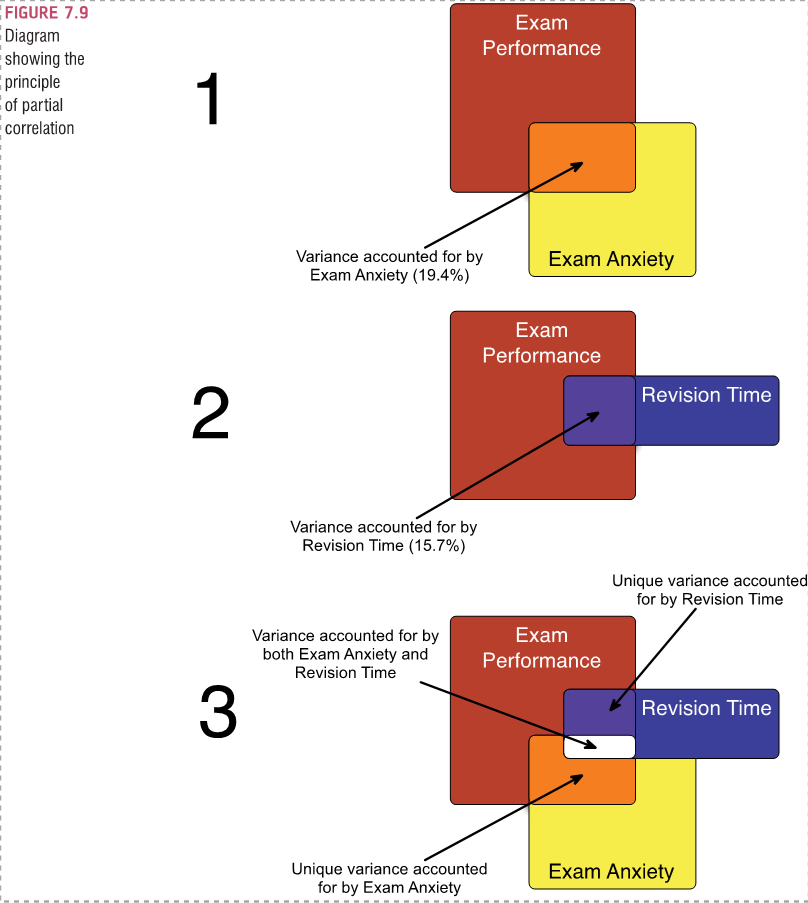